# ENCUESTA DE SATISFACCIÓN DIRIGIDA A BENEFICIARIOS DE PROYECTOS 2023

Universidad Pedagógica Nacional

Oficina de Desarrollo y Planeación

[figure not shown]

La encuesta de satisfacción dirigida a los beneficiarios de proectos 2023 fue respondida por **216** personas, de las cuales **216** dieron su autorización para el uso de sus datos en este análisis estadístico.

# Identidad de género

### Tabla

| Identidad de género | Cantidad |
| --- | --- |
| Femenino | 150 |
| Masculino | 63 |
| Otro | 2 |
| Total General | 215 |

### Gráfica

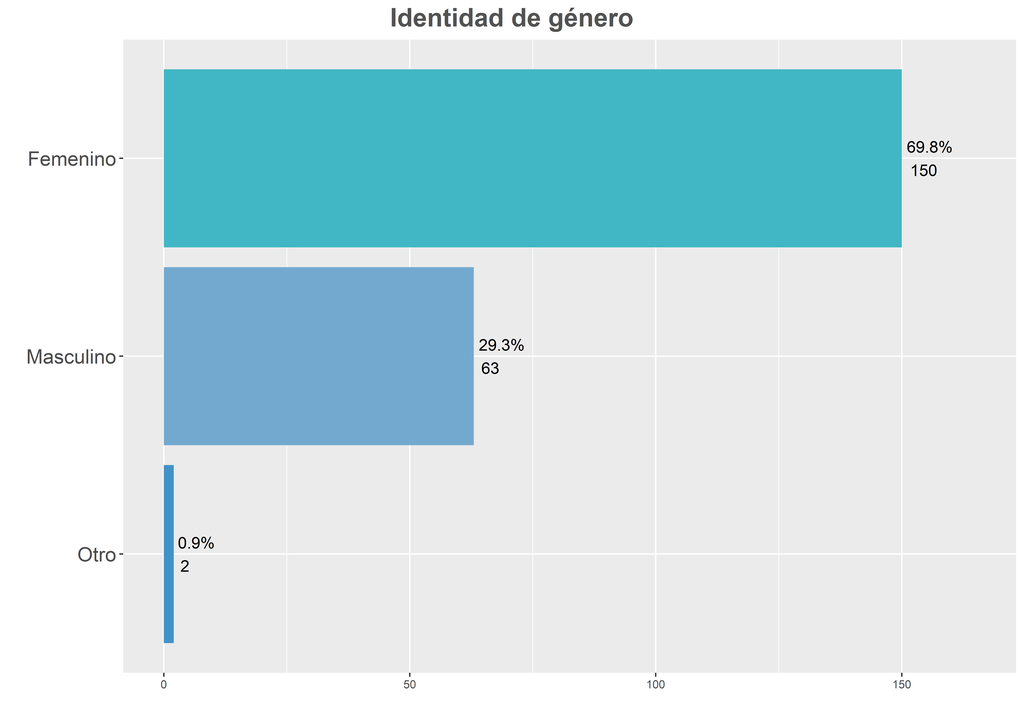

# Calificación y/o aporte por criterio de evaluación

En este apartado se muestran diferentes aspectos evaluados por los beneficiarios que respondieron la encuesta de satisfacción.

## Percepción de los encuestados frente a las actividades desarrolladas en el marco del proyecto

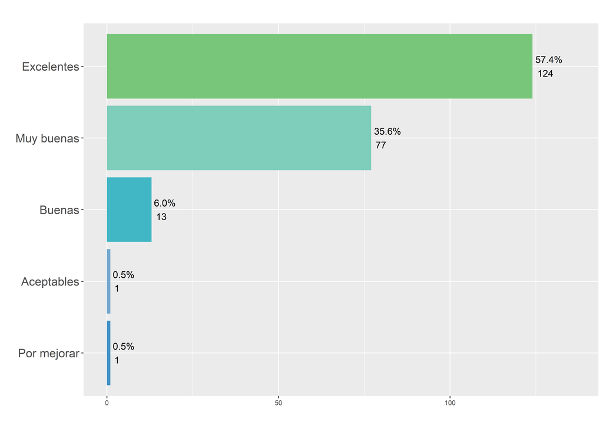

## ¿A consideración de los encuestados se cumplió con el objetivo planteado?

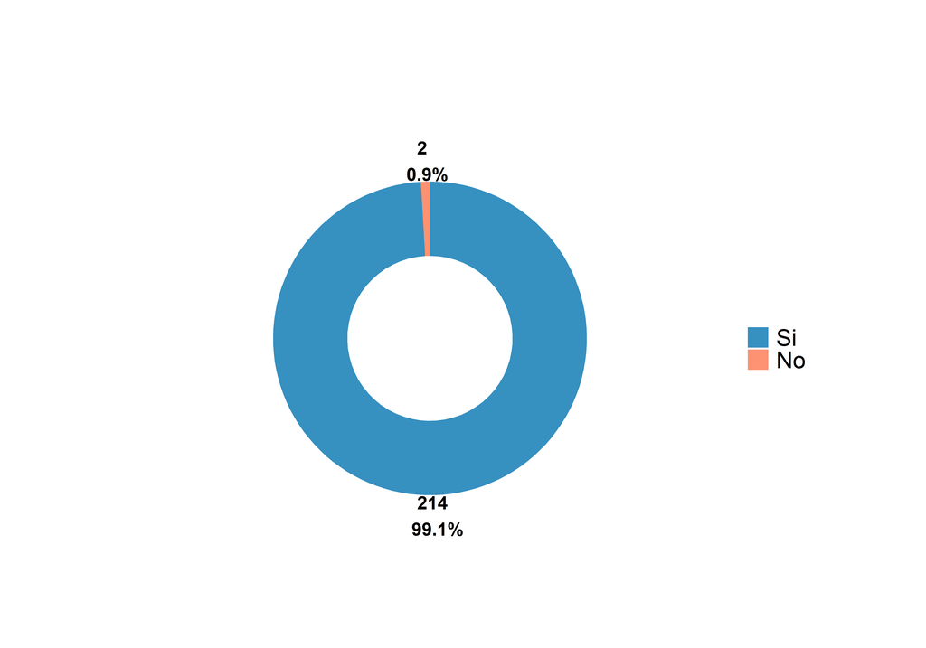

### En caso de que a percepción suya no se hayan cumplido dichos objetivos, ¿comunicó oportunamente dichas inquietudes al personal encargado para adoptar las medidas correctivas correspondientes?

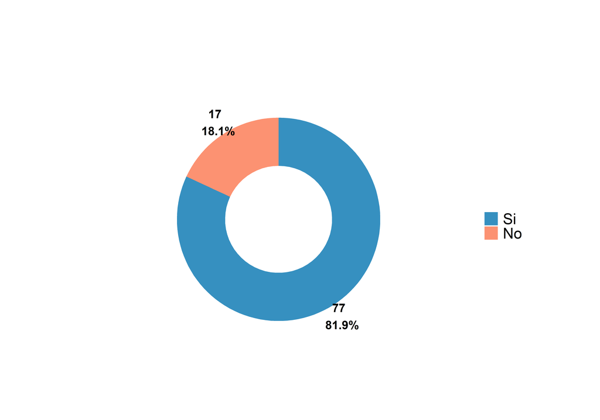

## ¿A consideración del encuestado se pueden mejorar las actividades planteadas en el proyecto?

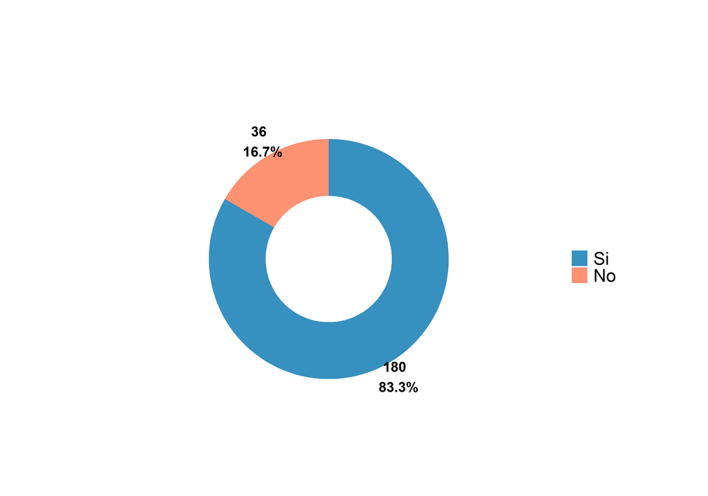

### Alternativas propuestas para mejorar las actividades planteadas

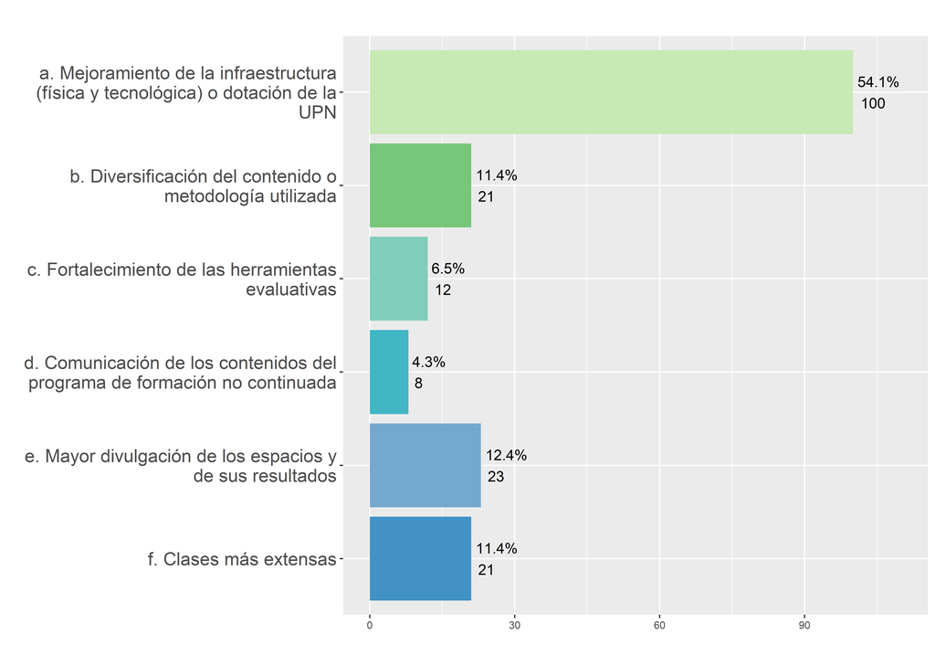

## A consideración de los encuestados el aporte personal que brindó el proyecto fue:

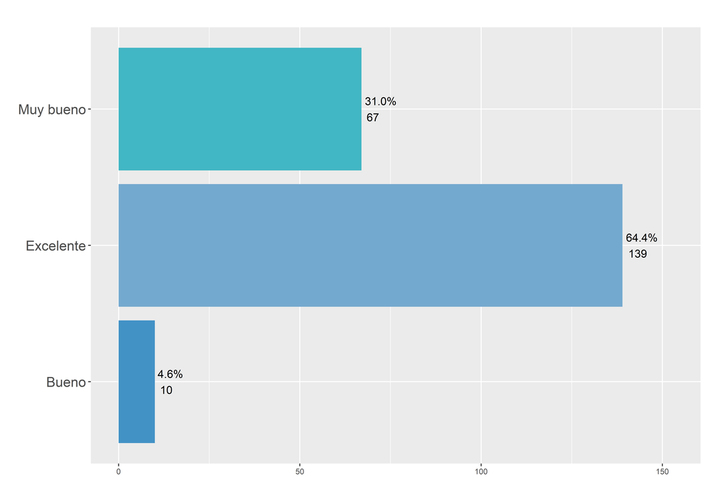